# Analysis of Software Carpentry’s Post-Workshop Surveys

**Author**: [Kari L. Jordan](https://github.com/kariljordan) **Contributors**: [Ben Marwick](https://github.com/benmarwick), and [Tracy Teal](https://github.com/tkteal) **Published**: April 2017

For nearly 20 years, Software Carpentry has developed material and trained instructors to teach computing skills to researchers in science, medicine, engineering, and other disciplines. This report is an analysis of the post-workshop survey responses collected for Software Carpentry’s workshops from March 2015 through March 2017. In this two year period, 3265 responses were collected.

A [PDF](https://github.com/carpentries/public-survey-info/blob/master/documents/surveys/2017-03-15-SwC-postworkshop-survey.pdf) of the survey questions, the data used in this analysis, and full R code are located on the public-survey-info repo on GitHub. Feel free to use the data and tell us about your findings.

```r
library(likert)
library(purrr)
```

### Learner Demographics

A host of initiatives have been developed and implemented globally to address gender disparities in computing. Software Carpentry’s volunteer instructors have hosted hundreds of events since 1998, and the post-workshop survey data shows **parity** in attendance of males compared to females.

```
##
##            Female              Male             Other Prefer not to say
##              1325              1322                10                55
```

```
##
##                  Commercial software developer
##                                             11
##                                        Faculty
##                                            185
##                               Graduate Student
##                                           1162
##                            Librarian/archivist
##                                             63
##                         Other (please specify)
##                                            147
##                       Post-doctoral researcher
##                                            458
## Research staff (including research programmer)
##                                            378
##    Support staff (including technical support)
##                                            116
##                          Undergraduate Student
##                                            197
```

### Learner Perception of Workshop Content and Atmosphere

Software Carpentry has developed an interactive instructional approach that includes direct instruction (i.e. explicit teaching and demonstrations), indirect instruction (i.e. problem solving and discovery), and experiential learning.

Learners were asked to rate their level of agreement on a scale of 1 (Strongly Disagree) to 5 (Strongly Agree) for the following statements regarding the atmosphere and content of the workshop they attended:  
* **Atmosphere**: The overall atmosphere of the workshop was welcoming.  
* **Recommend**: I would recommend this workshop to a friend/colleague.  
* **Material**: The material presented matched the workshop description.  
* **Worth**: The workshop was worth my time.  
* **Skills**: I learned skills that I will be able to use in my research/work.  
* **Information**: The amount of information covered at the workshop was reasonable for allotted time.

Learners have mixed feelings about the pace of the workshop they attended.

```
##
##    Just right Slightly fast Slightly slow      Too fast      Too slow
##          1101           876           616           137           140
```

```r
cols_with_Agree <- map_lgl(data, ~`%in%`("Agree", .x))
data_agree <-  data[ , cols_with_Agree]

order = c("Strongly Disagree", "Disagree", "Neither Agree nor Disagree", "Agree", "Strongly Agree")

print(class(data_agree))
```

```
## [1] "data.frame"
```

```r
data_agree <- map_if(data_agree,
                     is.character,
                     as.factor)

# Thanks [Elizabeth Wickes](hhttps://github.com/elliewix) for the tip!
for(i in seq_along(data_agree)) {
                data_agree[[i]] <- factor(data_agree[[i]], levels=order)
}

print(levels(data_agree))
```

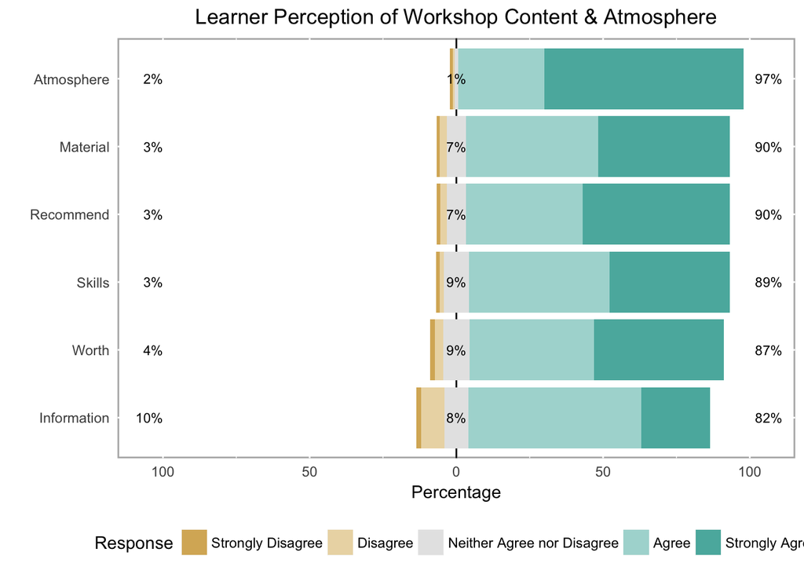

```r
title <- "Learner Perception of Workshop Content & Atmosphere"
data_agree_likert <-  likert(as.data.frame(data_agree))
theme_update(plot.title = element_text(hjust = 0.5))

plot(data_agree_likert) + ggtitle(title)
```

The data strongly suggests that Software Carpentry provides a welcoming environment for its learners where the material not only matches the workshop description, but is worth the time learners spend learning it. Learners acquire skills they are able to apply to their research or job function in the time alloted over the two-day period. Lastly, learners feel impressed to recommend the workshop to a friend or colleague.

### Learner Perception of Workshop Instructors and Helpers

A strength of Software Carpentry’s ecosystem is its instructors and helpers. Learners who responded to Software Carpentry’s post-workshop survey were asked to rate how they felt instructors and helpers worked as a team based on the following criteria:  
* **Instructors.Communicators**: Instructors were good communicators.  
* **Helpers.Clear.Answers**: Helpers gave clear answers to your questions.  
* **Helpers.Communicators**: Instructors were good communicators.  
* **Helpers Enthusiastic**: Helpers were enthusiastic.  
* **Instructors.Clear.Answers**: Instructors gave clear answers to your questions.  
* **Instructors.Enthusiastic**: Instructors were enthusiastic.  
* **Helpers.Considerate**: Helpers were considerate.  
* **Instructors.Considerate**: Instructors were considerate.

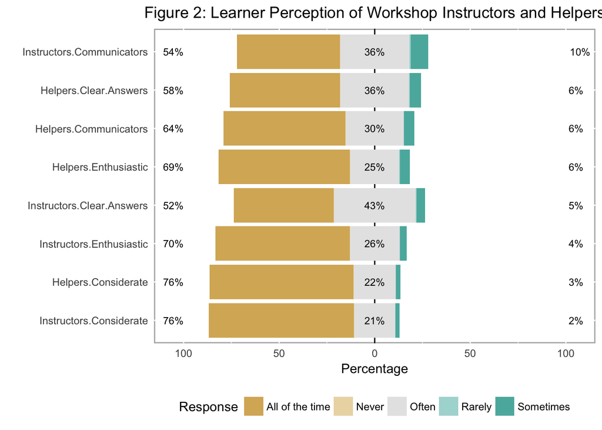

The data suggests that both Software Carpentry’s workshop instructors and helpers create an environment where learners are able to receive clear answers to their questions. Additionally, instructors and helpers communicate clearly with learners and are both enthusiastic about the material being taught and considerate of Software Carpentry learners.

### Learner Self-Reported Knowledge of Tools Covered

Software Carpentry workshops are self-organized, and each workshop includes the following **core topics**:  
* automating tasks using the Unix shell;  
* structured programming in Python, R, or MATLAB; and  
* version control using Git or Mercurial.

Learners were asked to indicate their level of knowledge of the Unix shell, R, Python, Git, and SQL prior to attending a Software Carpentry workshop.

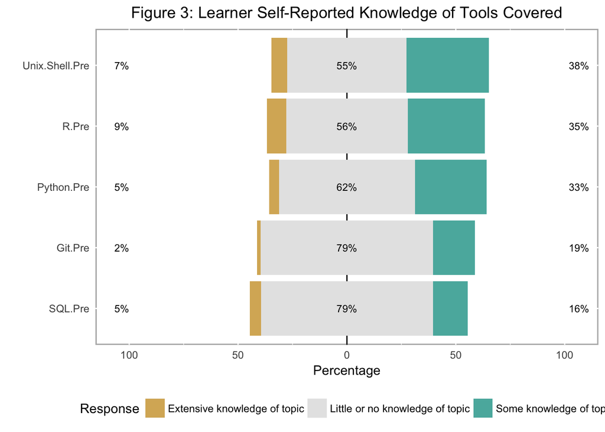

```r
cols_with_Little <- map_lgl(data, ~`%in%`("Little or no knowledge of topic", .x))
data_little <-  data[ , cols_with_Little]

data_little <- map_if(data_little,
                      is.character,
                      as.factor)
title <- "Figure 3: Learner Self-Reported Knowledge of Tools Covered"
data_little_likert <-  likert(as.data.frame(data_little))
plot(data_little_likert) + ggtitle(title)
```

Though some learners had prior knowledge of the tools covered in the workshop they attended, the majority had little to no knowledge of the topics covered, especially for SQL and Git. The following table shows a breakdown of how much information was new to learners attending a Software Carpentry workshop.

```
##
## About half of it        All of it       Most of it       None of it
##              684              416             1118               14
##       Some of it
##              511
```

Now let’s take a look at learners’ prior experience with the tools covered in the workshop they attended, and their knowledge and perception after the workshop. This section will be divided by tool:  
* Unix shell  
* Git  
* Python  
* R  
* SQL

### Learners’ Prior Experience and Knowledge Post-Workshop: Unix Shell